# Akanksha Dhall_ML_Project

**Part-A**

**Data Understanding:**

```python
#Libraries

import pandas as pd
import numpy as np

import seaborn as sns
import matplotlib.pyplot as plt
%matplotlib inline
import warnings
warnings.filterwarnings("ignore")

from sklearn.neighbors import KNeighborsClassifier
from scipy.stats import zscore

from imblearn.over_sampling import RandomOverSampler
from collections import Counter

from sklearn.model_selection import GridSearchCV

from sklearn.model_selection import train_test_split
from sklearn.metrics import classification_report

from sklearn.metrics import f1_score
from sklearn.metrics import accuracy_score
from sklearn.metrics import precision_score
from sklearn.metrics import recall_score
from sklearn import metrics
from array import *
from sklearn import preprocessing
from sklearn.metrics import roc_auc_score
```

```python
def multiclass_roc_auc_score(y_test, y_pred, average="macro"):
    lb = preprocessing.LabelBinarizer()
    lb.fit(y_test)
    y_test = lb.transform(y_test)
    y_pred = lb.transform(y_pred)
    return roc_auc_score(y_test, y_pred, average=average)
```

```python
def draw_confusion_matrix(y_value, predicted_value):
    cm=metrics.confusion_matrix(y_value, predicted_value, labels=["type_s", "type_h","normal"],)
    df_cm = pd.DataFrame(cm, index = [i for i in ["type_s", "type_h","normal"]],
                  columns = [i for i in ["type_s", "type_h","normal"]])
    sns.heatmap(df_cm, annot=True)
```

```python
  def performance_analysis(a,b):
    q=[]
    q.append(accuracy_score(a, b))
    q.append(precision_score(a, b,average="weighted"))
    q.append(recall_score(a, b,average="weighted"))
    q.append(f1_score(a, b,average="weighted"))
    q.append(multiclass_roc_auc_score(a, b, average="macro"))
    return q
```

```python
#1.A. Read all the 3 CSV files as DataFrame and store them into 3 separate variables.
df_n=pd.read_csv("Part1_Normal.csv")
df_h=pd.read_csv("Part1_Type_H.csv")
df_s=pd.read_csv("Part1_Type_S.csv")
```

```python
#1-B.Print Shape and columns of all the 3 DataFrames.
df_list=[df_n,df_h,df_s]
order=["first","second","third"]
for i in range(0, 3):
    print( "The shape of" ,order[i], "dataframe is ",df_list[i].shape)
    print( "The columns of" ,order[i], "dataframe is ",df_list[i].columns)
    print ("=======================================================================================")
```

```
The shape of first dataframe is  (100, 7)
The columns of first dataframe is  Index(['P_incidence', 'P_tilt', 'L_angle', 'S_slope', 'P_radius', 'S_Degree',
       'Class'],
      dtype='object')
=======================================================================================
The shape of second dataframe is  (60, 7)
The columns of second dataframe is  Index(['P_incidence', 'P_tilt', 'L_angle', 'S_slope', 'P_radius', 'S_Degree',
       'Class'],
      dtype='object')
=======================================================================================
The shape of third dataframe is  (150, 7)
The columns of third dataframe is  Index(['P_incidence', 'P_tilt', 'L_angle', 'S_slope', 'P_radius', 'S_Degree',
       'Class'],
      dtype='object')
=======================================================================================
```

```python
#1 C Compare Column names of all the 3 DataFrames and clearly write observations.
list1=df_n.columns
list2=df_h.columns
list3=df_s.columns

diff = len(list1.difference(list2))
result = (True if len(list1.difference(list3))==0 else False) if diff==0 else False

print("Columns of all datframes matched:", result)
```

```
Columns of all datframes matched: True
```

```python
#1. D Print DataTypes of all the 3 DataFrames.

df_list=[df_n,df_h,df_s]
order=["first","second","third"]
for i in range(0, 3):
    print( "The  Datatypes of" ,order[i], "dataframe")
    print(df_list[i].info())
    print ("=======================================================================================")
```

```
The  Datatypes of first dataframe
<class 'pandas.core.frame.DataFrame'>
RangeIndex: 100 entries, 0 to 99
Data columns (total 7 columns):
 #   Column       Non-Null Count  Dtype
---  ------       --------------  -----
 0   P_incidence  100 non-null    float64
 1   P_tilt       100 non-null    float64
 2   L_angle      100 non-null    float64
 3   S_slope      100 non-null    float64
 4   P_radius     100 non-null    float64
 5   S_Degree     100 non-null    float64
 6   Class        100 non-null    object
dtypes: float64(6), object(1)
memory usage: 5.6+ KB
None
=======================================================================================
The  Datatypes of second dataframe
<class 'pandas.core.frame.DataFrame'>
RangeIndex: 60 entries, 0 to 59
Data columns (total 7 columns):
 #   Column       Non-Null Count  Dtype
---  ------       --------------  -----
 0   P_incidence  60 non-null     float64
 1   P_tilt       60 non-null     float64
 2   L_angle      60 non-null     float64
 3   S_slope      60 non-null     float64
 4   P_radius     60 non-null     float64
 5   S_Degree     60 non-null     float64
 6   Class        60 non-null     object
dtypes: float64(6), object(1)
memory usage: 3.4+ KB
None
=======================================================================================
The  Datatypes of third dataframe
<class 'pandas.core.frame.DataFrame'>
RangeIndex: 150 entries, 0 to 149
Data columns (total 7 columns):
 #   Column       Non-Null Count  Dtype
---  ------       --------------  -----
 0   P_incidence  150 non-null    float64
 1   P_tilt       150 non-null    float64
 2   L_angle      150 non-null    float64
 3   S_slope      150 non-null    float64
 4   P_radius     150 non-null    float64
 5   S_Degree     150 non-null    float64
 6   Class        150 non-null    object
dtypes: float64(6), object(1)
memory usage: 8.3+ KB
None
=======================================================================================
```

The data type of all the columns are same across the all 3 data set.

```python
#1.E Observe and share variation in ‘Class’ feature of all the 3 DaraFrames.
df_list=[df_n,df_h,df_s]
order=["first","second","third"]
for i in range(0, 3):
    print("Class Feature of", order[i], "is:")
    print(df_list[i]['Class'].value_counts())
```

```
Class Feature of first is:
Normal    73
Nrmal     27
Name: Class, dtype: int64
Class Feature of second is:
Type_H    37
type_h    23
Name: Class, dtype: int64
Class Feature of third is:
Type_S    133
tp_s       17
Name: Class, dtype: int64
```

There is variation in the Class Feature. All values are not same on dataframes

**Data Preparation and Exploration:**

```python
#2.A Unify all the variations in ‘Class’ feature for all the 3 DataFrames

df_n['Class'].replace(to_replace="Normal",value="normal" , inplace=True, regex=True)
df_n['Class'].replace(to_replace="Nrmal",value="normal", inplace=True, regex=True)
df_h['Class'].replace(to_replace="Type_H",value="type_h", inplace=True, regex=True)
df_s['Class'].replace(to_replace="Type_S",value="type_s", inplace=True, regex=True)
df_s['Class'].replace(to_replace="tp_s",value="type_s", inplace=True, regex=True)
```

```python
# Verify the Class’ feature for all the 3 DataFrames after replace

df_list=[df_n,df_h,df_s]
order=["first","second","third"]
for i in range(0, 3):
    print("Class Feature of", order[i], "is:")
    print(df_list[i]['Class'].value_counts())
    print("**************************************************************")
```

```
Class Feature of first is:
normal    100
Name: Class, dtype: int64
Class Feature of second is:
type_h    60
Name: Class, dtype: int64
Class Feature of third is:
type_s    150
Name: Class, dtype: int64
```

```python
#2.B Combine all the 3 DataFrames to form a single DataFrame
df_combined=pd.concat([df_n, df_h,df_s], axis=0)
print("The data set has",df_combined.shape[0]," rows")
print("The data set has",df_combined.shape[1]," columns")
```

```
The data set has 310  rows
The data set has 7  columns
```

```python
#2.C Print 5 random samples of this DataFrame
df_combined.sample(5)
```

|  | P_incidence | P_tilt | L_angle | S_slope | P_radius | S_Degree | Class |
| --- | --- | --- | --- | --- | --- | --- | --- |
| 79 | 44.430701 | 14.174264 | 32.243495 | 30.256437 | 131.717613 | -3.604255 | normal |
| 67 | 65.756348 | 13.206926 | 44.000000 | 52.549422 | 129.393573 | -1.982120 | normal |
| 87 | 45.575482 | 18.759135 | 33.774143 | 26.816347 | 116.797007 | 3.131910 | normal |
| 30 | 50.819268 | 15.402213 | 42.528939 | 35.417055 | 112.192804 | 10.869566 | type_h |
| 9 | 58.599529 | -0.261499 | 51.500000 | 58.861028 | 102.042812 | 28.059697 | type_s |

```python
#2.D Print Feature-wise percentage of Null values.
df_combined.isnull().sum()*100/len(df_combined)
```

```
P_incidence    0.0
P_tilt         0.0
L_angle        0.0
S_slope        0.0
P_radius       0.0
S_Degree       0.0
Class          0.0
dtype: float64
```

The dataset contains no null value.

```python
#2. E Check 5-point summary of the new DataFrame
df_combined.describe().T
```

|  | count | mean | std | min | 25% | 50% | 75% | max |
| --- | --- | --- | --- | --- | --- | --- | --- | --- |
| P_incidence | 310.0 | 60.496653 | 17.236520 | 26.147921 | 46.430294 | 58.691038 | 72.877696 | 129.834041 |
| P_tilt | 310.0 | 17.542822 | 10.008330 | -6.554948 | 10.667069 | 16.357689 | 22.120395 | 49.431864 |
| L_angle | 310.0 | 51.930930 | 18.554064 | 14.000000 | 37.000000 | 49.562398 | 63.000000 | 125.742385 |
| S_slope | 310.0 | 42.953831 | 13.423102 | 13.366931 | 33.347122 | 42.404912 | 52.695888 | 121.429566 |
| P_radius | 310.0 | 117.920655 | 13.317377 | 70.082575 | 110.709196 | 118.268178 | 125.467674 | 163.071041 |
| S_Degree | 310.0 | 26.296694 | 37.559027 | -11.058179 | 1.603727 | 11.767934 | 41.287352 | 418.543082 |

**Data Analysis**

```python
#3.A Visualize a heatmap to understand correlation between all features

def heat_map(DF_name,Title):
    plt.figure(figsize= (5,4))
    sns.heatmap(DF_name.corr(),annot=True)
    plt.yticks(rotation = 0)
    plt.xticks(rotation = 90)
    plt.title(Title)
    plt.show()
```

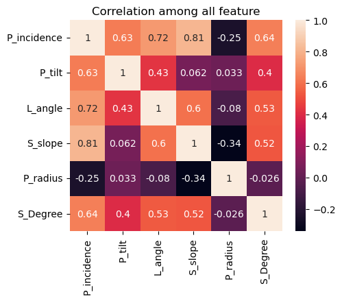

```python
heat_map(df_combined,'Correlation among all feature')
```

#3 B.A Features having stronger correlation with correlation value The strong positive correlation is between P_incidence and S_slope=.81.

#3.B.B.Features having weaker correlation with correlation value. P_radius and S_slope=-0.34 P_radius and P_incidence =-0.25 S_Degree and P_tilt =0.4 P_tilt and L_angle= 0.43

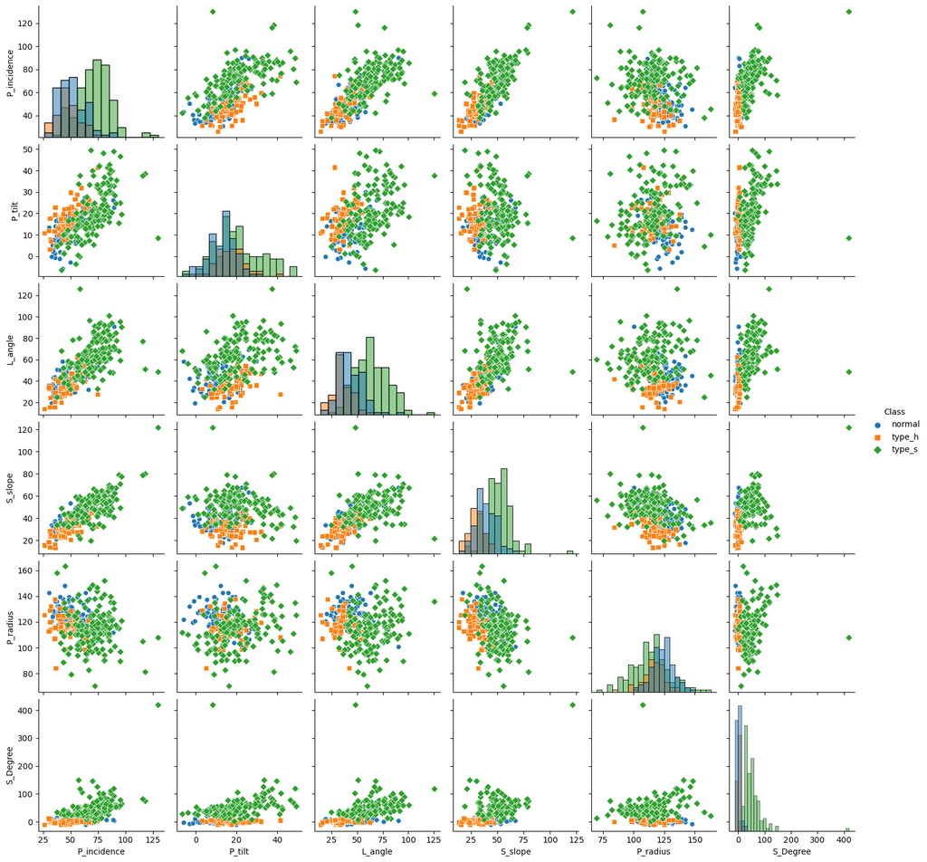

```python
#3.C Visualize a pairplot with 3 classes distinguished by colors and share insights
sns.pairplot(df_combined,hue='Class',diag_kind="hist" ,markers=["o", "s", "D"])
```

type_s class dominate over normal and type_h class. In S_degree, normal class has higher peak than type_s class. Overall type_s class data spead is largest.

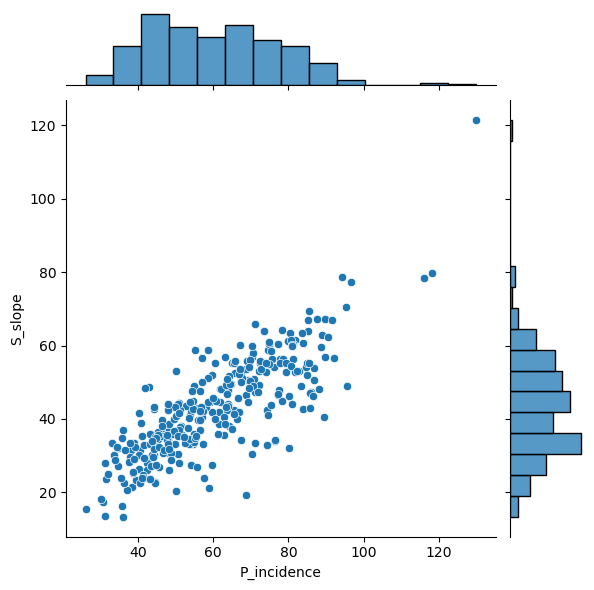

```python
#3.D Visualize a jointplot for ‘P_incidence’ and ‘S_slope’ and share insights.
sns.jointplot(data =df_combined, x="P_incidence", y="S_slope")
```

There is linear positive and strong correlation between "P_incidence" and "S_slope" .

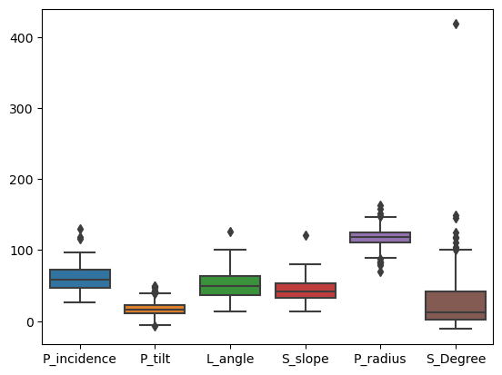

```python
#3.E Visualize a boxplot to check distribution of the features and share insights.
sns.boxplot(data=df_combined)
plt.show()
```

In S_degree, data is not equally distributted as we can see median is towards left side. (Positive Skweness). Outliers are very far from max range. We need to check is it info or noise? Other than S_degree other features have normally distributted data. Few have 1 side outliers like P_incidence, L_angle,S_slope and P_tilt and P_radius has 2 side outliers.

**Model Building**

```python
#As I can check in further steps we are using this dataset for modelling. So performing the data preparation.
```

```python
df_KNN=df_combined.copy()

#As we can check from above cell the data type of Class is object. Coverting it into category.
df_KNN.Class= df_KNN.Class.astype('category')
df_KNN.Class.dtype
```

```
CategoricalDtype(categories=['normal', 'type_h', 'type_s'], ordered=False)
```

```python
#4. A Split data into X and Y.

Y=df_KNN['Class']
X=df_KNN.drop('Class', axis=1)

#Convert all the values in Z- scale
XScaled  = X.apply(zscore)
XScaled.sample(5)
```

|  | P_incidence | P_tilt | L_angle | S_slope | P_radius | S_Degree |
| --- | --- | --- | --- | --- | --- | --- |
| 146 | 2.032901 | 2.902995 | 0.381614 | 0.445948 | -1.597243 | 1.359695 |
| 148 | 1.579575 | 0.282500 | 2.261457 | 1.817689 | 0.227452 | 1.344962 |
| 95 | 0.366567 | -0.299356 | 1.087986 | 0.693908 | -2.667339 | 0.410385 |
| 23 | -1.151361 | -0.840096 | -1.128763 | -0.852076 | 1.594315 | -0.768254 |
| 38 | -0.270408 | 1.131348 | -0.228912 | -1.190767 | 0.405478 | -0.626274 |

```python
#4.B Split data into train and test with 80:20 proportion.
X_train, X_test, Y_train, Y_test = train_test_split(XScaled, Y, test_size=0.20, random_state=10)
print("X_train Shape", X_train.shape)
print("X_test Shape" ,X_test.shape)
print("Y_train Shape", Y_train.shape)
print("Y_test Shape" ,Y_test.shape)
```

```
X_train Shape (248, 6)
X_test Shape (62, 6)
Y_train Shape (248,)
Y_test Shape (62,)
```

```python
#4.C Train a Supervised Learning Classification base model using KNN classifier
```

```python
KNN_1 = KNeighborsClassifier()
KNN_1.fit(X_train, Y_train)
```

```
KNeighborsClassifier()
```

```python
#4.D Performance evalution of KNN.
knn1_predicted_label_test= KNN_1.predict(X_test)
knn1_predicted_labels_train = KNN_1.predict(X_train)
KNN_Train_data=performance_analysis(Y_train,knn1_predicted_labels_train)
KNN_Test_data=performance_analysis(Y_test,knn1_predicted_label_test)
```

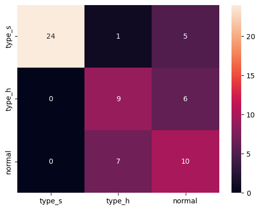

```python
#Confusion matrix on test data
draw_confusion_matrix(Y_test, knn1_predicted_label_test )
```

```python
#Performance anaysis on training data

report = classification_report(Y_train,knn1_predicted_labels_train)

print(report)
```

```
              precision    recall  f1-score   support

      normal       0.83      0.83      0.83        83
      type_h       0.77      0.80      0.78        45
      type_s       0.94      0.93      0.93       120

    accuracy                           0.87       248
   macro avg       0.85      0.85      0.85       248
weighted avg       0.87      0.87      0.87       248
```

```python
#Performance analysis On test data

report = classification_report(Y_test,knn1_predicted_label_test)

print(report)
```

```
              precision    recall  f1-score   support

      normal       0.48      0.59      0.53        17
      type_h       0.53      0.60      0.56        15
      type_s       1.00      0.80      0.89        30

    accuracy                           0.69        62
   macro avg       0.67      0.66      0.66        62
weighted avg       0.74      0.69      0.71        62
```

```python
data= { 'KNN_train' : KNN_Train_data,
        'KNN_test' :  KNN_Test_data
       }

Name= ['Accuracy', 'Recall', 'Precision', 'F1-score',"roc_auc_score"]
index=Name
df = pd.DataFrame(data, index)
df.reset_index(inplace = True)

display(df)
```

|  | index | KNN_train | KNN_test |
| --- | --- | --- | --- |
| 0 | Accuracy | 0.870968 | 0.693548 |
| 1 | Recall | 0.872377 | 0.742523 |
| 2 | Precision | 0.870968 | 0.693548 |
| 3 | F1-score | 0.871573 | 0.710509 |
| 4 | roc_auc_score | 0.893767 | 0.762263 |

**Performance Improvement**

```python
#distribution of data is imbalance
Y.value_counts()
```

```
type_s    150
normal    100
type_h     60
Name: Class, dtype: int64
```

```python
#Performing the RandomOverSampler to handle imbalanced data

ROS =  RandomOverSampler()
X_ros1, y_ros1 = ROS.fit_resample(X,Y)
X_ros1.shape,y_ros1.shape
```

```
((450, 6), (450,))
```

```python
X_train_ros, X_test_ros, y_train_ros, y_test_ros = train_test_split(X_ros1, y_ros1, test_size=0.25, random_state=10)

print('Original dataset shape {}'.format(Counter(Y)))
print('After Over sampling shape {}'.format(Counter(y_ros1)))
print('Resampled dataset shape {}'.format(Counter(y_train_ros)))
print('Resampled dataset shape {}'.format(Counter(y_test_ros)))
```

```
Original dataset shape Counter({'type_s': 150, 'normal': 100, 'type_h': 60})
After Over sampling shape Counter({'normal': 150, 'type_h': 150, 'type_s': 150})
Resampled dataset shape Counter({'normal': 116, 'type_h': 112, 'type_s': 109})
Resampled dataset shape Counter({'type_s': 41, 'type_h': 38, 'normal': 34})
```

```
{'leaf_size': 1, 'metric': 'euclidean', 'n_neighbors': 4, 'weights': 'distance'}
```

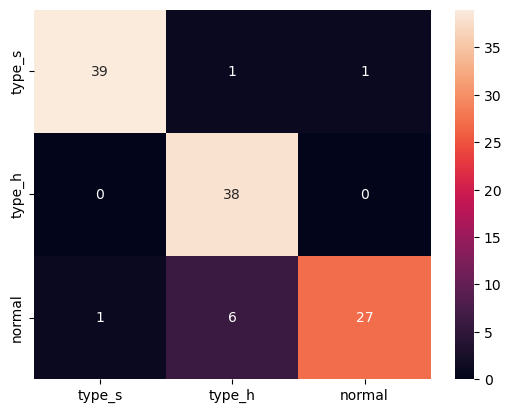

```python
#5.A Experiment with various parameters to improve performance of the base model.
leaf_size = list(range(1,50))
n_neighbors = list(range(1,30))
weights = ['uniform', 'distance']
metric = ['euclidean', 'manhattan', 'minkowski']

hyperparameters = dict(leaf_size=leaf_size, n_neighbors=n_neighbors,weights= weights,metric= metric)


knn_2 = KNeighborsClassifier()
model1 = GridSearchCV(knn_2, hyperparameters, cv=5)
best_model = model1.fit(X_train_ros,y_train_ros)

print(best_model.best_params_)
knn2_predicted_labels_train = best_model.predict(X_train_ros)
knn2_predicted_label_test= best_model.predict(X_test_ros)
draw_confusion_matrix(y_test_ros, knn2_predicted_label_test)
```

```python
BROS_KNN_train=performance_analysis(y_train_ros, knn2_predicted_labels_train)
BROS_KNN_test=performance_analysis(y_test_ros, knn2_predicted_label_test)
df['BROS_KNN_train'] = BROS_KNN_train
df['BROS_KNN_test']=BROS_KNN_test
df
```

|  | index | KNN_train | KNN_test | BROS_KNN_train | BROS_KNN_test |
| --- | --- | --- | --- | --- | --- |
| 0 | Accuracy | 0.870968 | 0.693548 | 1.0 | 0.920354 |
| 1 | Recall | 0.872377 | 0.742523 | 1.0 | 0.927873 |
| 2 | Precision | 0.870968 | 0.693548 | 1.0 | 0.920354 |
| 3 | F1-score | 0.871573 | 0.710509 | 1.0 | 0.919377 |
| 4 | roc_auc_score | 0.893767 | 0.762263 | 1.0 | 0.937576 |

```python
print(classification_report(y_test_ros, knn2_predicted_label_test))
```

```
              precision    recall  f1-score   support

      normal       0.96      0.79      0.87        34
      type_h       0.84      1.00      0.92        38
      type_s       0.97      0.95      0.96        41

    accuracy                           0.92       113
   macro avg       0.93      0.92      0.92       113
weighted avg       0.93      0.92      0.92       113
```

```python
#5 BClearly showcase improvement in performance achieved
#Calculate the percentage-
df['Improvement']= ((df['BROS_KNN_test']-df['KNN_test'])/df['KNN_test'])*100
df
```

|  | index | KNN_train | KNN_test | BROS_KNN_train | BROS_KNN_test | Improvement |
| --- | --- | --- | --- | --- | --- | --- |
| 0 | Accuracy | 0.870968 | 0.693548 | 1.0 | 0.920354 | 32.702202 |
| 1 | Recall | 0.872377 | 0.742523 | 1.0 | 0.927873 | 24.962166 |
| 2 | Precision | 0.870968 | 0.693548 | 1.0 | 0.920354 | 32.702202 |
| 3 | F1-score | 0.871573 | 0.710509 | 1.0 | 0.919377 | 29.396976 |
| 4 | roc_auc_score | 0.893767 | 0.762263 | 1.0 | 0.937576 | 22.999031 |

```python
parameters = ['Accuracy', 'Recall', 'Precision', 'F1-score',"roc_auc_score"]
counter=np.arange(0, 6)
for i,j in zip(parameters,counter):
    print( i," is increased by ",df['Improvement'][j] )
```

```
Accuracy  is increased by  32.70220209919735
Recall  is increased by  24.962166144811103
Precision  is increased by  32.70220209919735
F1-score  is increased by  29.396976451125216
roc_auc_score  is increased by  22.999030654206695
```

# 5C Clearly state which parameters contributed most to improve model performance.

Balancing the dataset heps the most to improve the model.

```python
print(best_model.best_params_)
```

```
{'leaf_size': 1, 'metric': 'euclidean', 'n_neighbors': 4, 'weights': 'distance'}
```

**Part B**

**Data Understanding and Preparation**

```python
import pandas as pd
import numpy as np

import seaborn as sns
import matplotlib.pyplot as plt

import warnings
warnings.filterwarnings("ignore")

from sklearn import metrics

from sklearn.metrics import classification_report
from imblearn.over_sampling import RandomOverSampler
from imblearn.under_sampling import RandomUnderSampler

from sklearn import preprocessing
from sklearn.model_selection import train_test_split
from sklearn.linear_model import LogisticRegression
from sklearn.neighbors import KNeighborsClassifier
from sklearn.svm import SVC
from sklearn.preprocessing import StandardScaler
from sklearn.model_selection import GridSearchCV
from sklearn.metrics import f1_score
from sklearn.metrics import accuracy_score
from sklearn.metrics import precision_score
from sklearn.metrics import recall_score
from sklearn import metrics
from collections import Counter
from sklearn import preprocessing
from sklearn.metrics import roc_auc_score
```

```python
def performance_analysis2(a,b):
    q=[]
    q.append(accuracy_score(a, b))
    q.append(precision_score(a, b,average="macro"))
    q.append(recall_score(a, b,average="macro"))
    q.append(f1_score(a, b,average="macro"))
    q.append(multiclass_roc_auc_score(a, b, average="macro"))
    return q



def test_train_analysis(ytrain,ytest,predict_train,predict_test):
    train=performance_analysis2(ytrain,predict_train)
    test=performance_analysis2(ytest,predict_test)
    data= { 'train' : train,
            'test' :test
       }

    Name= ['Accuracy', 'Recall', 'Precision', 'F1-score',"roc_auc_score"]
    index=Name
    df2 = pd.DataFrame(data, index)
    df2.reset_index(inplace = True)
    display(df2)
```

```python
def multiclass_roc_auc_score(y_test, y_pred, average="macro"):
    lb = preprocessing.LabelBinarizer()
    lb.fit(y_test)
    y_test = lb.transform(y_test)
    y_pred = lb.transform(y_pred)
    return roc_auc_score(y_test, y_pred, average=average)
```

```python
def logisticR(xtrain,ytrain,xtest,ytest):
    logit = LogisticRegression()
    logit.fit(xtrain, ytrain)
    logit_pred_test = logit.predict(xtest)
    logit_pred_train = logit.predict(xtrain)
    test_train_analysis(ytrain,ytest,logit_pred_train,logit_pred_test)
    print ("classification_report of training data")
    print(classification_report(ytrain, logit_pred_train))
    print("Confusion metrics of test data")
    print(classification_report(ytest, logit_pred_test))
```

```python
def conf_metrix(y,pred):
    cm = metrics.confusion_matrix(y, pred, labels=[0, 1])
    df_cm = pd.DataFrame(cm, index = [i for i in ["Loan on card - No","Loan on Card - Yes"]],
                  columns = [i for i in ["Loan on card - No","Loan on Card - Yes"]])
    plt.figure(figsize = (7,5))
    sns.heatmap(df_cm, annot=True,fmt= 'd')
    plt.show()
```

```python
def svc_RegModel(xtrain, ytrain, xtest,ytest,kernel1):
    svc_model = SVC(C= .1, kernel=kernel1, gamma= 1)
    svc_model.fit(xtrain, ytrain)
    prediction_test = svc_model .predict(xtest)
    prediction_train = svc_model .predict(xtrain)
    test_train_analysis(ytrain,ytest,prediction_train,prediction_test)
    print ("classification_report of test data")
    print(classification_report(ytest,prediction_test))
```

```python
def general_method(a):
    a.fit(X_train_ros, y_train_ros)
    prediction_test = a .predict(X_test_ros)
    prediction_train = a .predict(X_train_ros)
    test_train_analysis(y_train_ros,y_test_ros,prediction_train,prediction_test)
    print ("classification_report of test data")
    print(classification_report(y_test_ros,prediction_test))
```

```python
#1 A Read both the Datasets ‘Data1’ and ‘Data 2’ as DataFrame and store them into two separate variables.

data1=pd.read_csv("Data1.csv")
data2=pd.read_csv("Data2.csv")
```

```python
#1.B Print shape and Column Names and DataTypes of both the Dataframes
df_list2=[data1,data2]
order=["first","second"]
for i in range(0, 2):
    print( "The shape of" ,order[i], "dataframe is ",df_list2[i].shape)
    print( "The columns of" ,order[i], "dataframe are ",df_list2[i].columns)
    print( "The data types of" ,order[i], "dataframe is \n",df_list2[i].dtypes)
    print ("=======================================================================================")
```

```
The shape of first dataframe is  (5000, 8)
The columns of first dataframe are  Index(['ID', 'Age', 'CustomerSince', 'HighestSpend', 'ZipCode', 'HiddenScore',
       'MonthlyAverageSpend', 'Level'],
      dtype='object')
The data types of first dataframe is
 ID                       int64
Age                      int64
CustomerSince            int64
HighestSpend             int64
ZipCode                  int64
HiddenScore              int64
MonthlyAverageSpend    float64
Level                    int64
dtype: object
=======================================================================================
The shape of second dataframe is  (5000, 7)
The columns of second dataframe are  Index(['ID', 'Mortgage', 'Security', 'FixedDepositAccount', 'InternetBanking',
       'CreditCard', 'LoanOnCard'],
      dtype='object')
The data types of second dataframe is
 ID                       int64
Mortgage                 int64
Security                 int64
FixedDepositAccount      int64
InternetBanking          int64
CreditCard               int64
LoanOnCard             float64
dtype: object
=======================================================================================
```

```python
data1.tail(5)
```

|  | ID | Age | CustomerSince | HighestSpend | ZipCode | HiddenScore | MonthlyAverageSpend | Level |
| --- | --- | --- | --- | --- | --- | --- | --- | --- |
| 4995 | 4996 | 29 | 3 | 40 | 92697 | 1 | 1.9 | 3 |
| 4996 | 4997 | 30 | 4 | 15 | 92037 | 4 | 0.4 | 1 |
| 4997 | 4998 | 63 | 39 | 24 | 93023 | 2 | 0.3 | 3 |
| 4998 | 4999 | 65 | 40 | 49 | 90034 | 3 | 0.5 | 2 |
| 4999 | 5000 | 28 | 4 | 83 | 92612 | 3 | 0.8 | 1 |

```python
data2.tail(5)
```

|  | ID | Mortgage | Security | FixedDepositAccount | InternetBanking | CreditCard | LoanOnCard |
| --- | --- | --- | --- | --- | --- | --- | --- |
| 4995 | 4996 | 0 | 0 | 0 | 1 | 0 | 0.0 |
| 4996 | 4997 | 85 | 0 | 0 | 1 | 0 | 0.0 |
| 4997 | 4998 | 0 | 0 | 0 | 0 | 0 | 0.0 |
| 4998 | 4999 | 0 | 0 | 0 | 1 | 0 | 0.0 |
| 4999 | 5000 | 0 | 0 | 0 | 1 | 1 | 0.0 |

```python
#1.C Merge both the Dataframes on ‘ID’ feature to form a single DataFrame
df_new=pd.merge(data1, data2, on='ID')
```

```python
df_new.head()
```

|  | ID | Age | CustomerSince | HighestSpend | ZipCode | HiddenScore | MonthlyAverageSpend | Level | Mortgage | Security | FixedDepositAccount | InternetBanking | CreditCard | LoanOnCard |
| --- | --- | --- | --- | --- | --- | --- | --- | --- | --- | --- | --- | --- | --- | --- |
| 0 | 1 | 25 | 1 | 49 | 91107 | 4 | 1.6 | 1 | 0 | 1 | 0 | 0 | 0 | NaN |
| 1 | 2 | 45 | 19 | 34 | 90089 | 3 | 1.5 | 1 | 0 | 1 | 0 | 0 | 0 | NaN |
| 2 | 3 | 39 | 15 | 11 | 94720 | 1 | 1.0 | 1 | 0 | 0 | 0 | 0 | 0 | NaN |
| 3 | 4 | 35 | 9 | 100 | 94112 | 1 | 2.7 | 2 | 0 | 0 | 0 | 0 | 0 | NaN |
| 4 | 5 | 35 | 8 | 45 | 91330 | 4 | 1.0 | 2 | 0 | 0 | 0 | 0 | 1 | NaN |

```python
#1.D Change Datatype of below features to ‘Object’ [
col=['CreditCard', 'InternetBanking', 'FixedDepositAccount', 'Security', 'Level', 'HiddenScore']
for i in col:
    df_new[i]=df_new[i].astype('category')
df_new.dtypes
```

```
ID                        int64
Age                       int64
CustomerSince             int64
HighestSpend              int64
ZipCode                   int64
HiddenScore            category
MonthlyAverageSpend     float64
Level                  category
Mortgage                  int64
Security               category
FixedDepositAccount    category
InternetBanking        category
CreditCard             category
LoanOnCard              float64
dtype: object
```

```python
df_new.head()
```

|  | ID | Age | CustomerSince | HighestSpend | ZipCode | HiddenScore | MonthlyAverageSpend | Level | Mortgage | Security | FixedDepositAccount | InternetBanking | CreditCard | LoanOnCard |
| --- | --- | --- | --- | --- | --- | --- | --- | --- | --- | --- | --- | --- | --- | --- |
| 0 | 1 | 25 | 1 | 49 | 91107 | 4 | 1.6 | 1 | 0 | 1 | 0 | 0 | 0 | NaN |
| 1 | 2 | 45 | 19 | 34 | 90089 | 3 | 1.5 | 1 | 0 | 1 | 0 | 0 | 0 | NaN |
| 2 | 3 | 39 | 15 | 11 | 94720 | 1 | 1.0 | 1 | 0 | 0 | 0 | 0 | 0 | NaN |
| 3 | 4 | 35 | 9 | 100 | 94112 | 1 | 2.7 | 2 | 0 | 0 | 0 | 0 | 0 | NaN |
| 4 | 5 | 35 | 8 | 45 | 91330 | 4 | 1.0 | 2 | 0 | 0 | 0 | 0 | 1 | NaN |

**Data Exploration and Analysis**

```python
#2.A Visualize distribution of Target variable ‘LoanOnCard’ and clearly share insights.
df_new.isna().sum()
```

```
ID                      0
Age                     0
CustomerSince           0
HighestSpend            0
ZipCode                 0
HiddenScore             0
MonthlyAverageSpend     0
Level                   0
Mortgage                0
Security                0
FixedDepositAccount     0
InternetBanking         0
CreditCard              0
LoanOnCard             20
dtype: int64
```

LoanOnCard has 20 NAN values.

```python
#The data type of LoanonCard fiield is - Float, So changing it also in category.
df_new['LoanOnCard']=df_new['LoanOnCard'].astype('category')
df_new['LoanOnCard'].dtypes
```

```
CategoricalDtype(categories=[0.0, 1.0], ordered=False)
```

```
Count of Loan on card
0.0    4500
1.0     480
Name: LoanOnCard, dtype: int64
==============
Check the unique values in data frame [NaN, 1.0, 0.0]
Categories (2, float64): [0.0, 1.0]
```

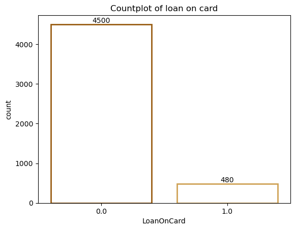

```python
print("Count of Loan on card")
print(df_new['LoanOnCard'].value_counts())
print ("==============")
print("Check the unique values in data frame", df_new.LoanOnCard.unique())
ax=sns.countplot(x ='LoanOnCard', data = df_new, facecolor=(0, 0, 0, 0), linewidth=2, edgecolor=sns.color_palette("BrBG", 7))
for i in ax.containers:
    ax.bar_label(i,)
    ax.set(title='Countplot of loan on card')
plt.show()
```

```python
df_new.LoanOnCard.count()
```

```
4980
```

4500 people out of 4980 people have not loan on card. 480 people out of 4980 peole has loan on on card. For 20 people we do not have info.

```python
#2. B Check the percentage of missing values and impute if required.
df_new.isnull().sum() * 100 / len(df_new)
```

```
ID                     0.0
Age                    0.0
CustomerSince          0.0
HighestSpend           0.0
ZipCode                0.0
HiddenScore            0.0
MonthlyAverageSpend    0.0
Level                  0.0
Mortgage               0.0
Security               0.0
FixedDepositAccount    0.0
InternetBanking        0.0
CreditCard             0.0
LoanOnCard             0.4
dtype: float64
```

```python
#2.C Check if thereis any missing orcorrupted data in categorical columns.
col=['CreditCard', 'InternetBanking', 'FixedDepositAccount', 'Security', 'Level', 'HiddenScore','LoanOnCard']
for i in col:
    print(i)
    print(df_new[i].unique())
    print("****************************")
```

```
CreditCard
[0, 1]
Categories (2, int64): [0, 1]
InternetBanking
[0, 1]
Categories (2, int64): [0, 1]
FixedDepositAccount
[0, 1]
Categories (2, int64): [0, 1]
Security
[1, 0]
Categories (2, int64): [0, 1]
Level
[1, 2, 3]
Categories (3, int64): [1, 2, 3]
HiddenScore
[4, 3, 1, 2]
Categories (4, int64): [1, 2, 3, 4]
LoanOnCard
[NaN, 1.0, 0.0]
Categories (2, float64): [0.0, 1.0]
```

```python
#As we can check there is only column whuch has missing value is LoanOnCard. And It is catagorical data - either yes or no.
#So using the mode method to impute the data
df_new['LoanOnCard'] = df_new['LoanOnCard'].fillna(df_new['LoanOnCard'].mode().iloc[0])
df_new['LoanOnCard'].unique()
```

```
[0.0, 1.0]
Categories (2, float64): [0.0, 1.0]
```

```python
df_new.isna().sum()
```

```
ID                     0
Age                    0
CustomerSince          0
HighestSpend           0
ZipCode                0
HiddenScore            0
MonthlyAverageSpend    0
Level                  0
Mortgage               0
Security               0
FixedDepositAccount    0
InternetBanking        0
CreditCard             0
LoanOnCard             0
dtype: int64
```

Now there is no NAN value in the dataset.

**Data Preparation and model building:**

```python
#3.A Split data into X and Y.


label_encoder = preprocessing.LabelEncoder()

#update the 'HiddenScore','Level','LoanOnCard' in ordinal numbers, other categorical columns has already 0 or 1 value.
for i in ['HiddenScore','Level','LoanOnCard']:

    df_new[i]= label_encoder.fit_transform(df_new[i])
    print("Unique values of ",i +" are ", df_new[i].unique())
```

```
Unique values of  HiddenScore are  [3 2 0 1]
Unique values of  Level are  [0 1 2]
Unique values of  LoanOnCard are  [0 1]
```

```python
#Create indepenent and dependent data
X=df_new.drop(['ID','ZipCode','LoanOnCard'], axis=1)
Y=df_new['LoanOnCard']
```

```python
X.head(5)
```

|  | Age | CustomerSince | HighestSpend | HiddenScore | MonthlyAverageSpend | Level | Mortgage | Security | FixedDepositAccount | InternetBanking | CreditCard |
| --- | --- | --- | --- | --- | --- | --- | --- | --- | --- | --- | --- |
| 0 | 25 | 1 | 49 | 3 | 1.6 | 0 | 0 | 1 | 0 | 0 | 0 |
| 1 | 45 | 19 | 34 | 2 | 1.5 | 0 | 0 | 1 | 0 | 0 | 0 |
| 2 | 39 | 15 | 11 | 0 | 1.0 | 0 | 0 | 0 | 0 | 0 | 0 |
| 3 | 35 | 9 | 100 | 0 | 2.7 | 1 | 0 | 0 | 0 | 0 | 0 |
| 4 | 35 | 8 | 45 | 3 | 1.0 | 1 | 0 | 0 | 0 | 0 | 1 |

```python
Y.head(5)
```

```
0    0
1    0
2    0
3    0
4    0
Name: LoanOnCard, dtype: int64
```

```python
#3.B Split data into train and test. Keep 25% data reserved for testing.

X_train, X_test, Y_train, Y_test = train_test_split(X, Y, test_size=0.25,random_state=10)
print("X_train Shape", X_train.shape)
print("X_test Shape" ,X_test.shape)
print("Y_train Shape", Y_train.shape)
print("Y_test Shape" ,Y_test.shape)
```

```
X_train Shape (3750, 11)
X_test Shape (1250, 11)
Y_train Shape (3750,)
Y_test Shape (1250,)
```

```python
# Train a Supervised Learning Classification base model - Logistic Regression.
# Print evaluation metrics for the model and clearly share insights
# Performance anaysis on test data
logisticR(X_train,Y_train,X_test,Y_test)
```

|  | index | train | test |
| --- | --- | --- | --- |
| 0 | Accuracy | 0.949067 | 0.949600 |
| 1 | Recall | 0.883213 | 0.885711 |
| 2 | Precision | 0.805065 | 0.790359 |
| 3 | F1-score | 0.838460 | 0.829582 |
| 4 | roc_auc_score | 0.805065 | 0.790359 |

```
classification_report of training data
              precision    recall  f1-score   support

           0       0.96      0.98      0.97      3386
           1       0.81      0.63      0.70       364

    accuracy                           0.95      3750
   macro avg       0.88      0.81      0.84      3750
weighted avg       0.95      0.95      0.95      3750

Confusion metrics of test data
              precision    recall  f1-score   support

           0       0.96      0.99      0.97      1134
           1       0.81      0.59      0.69       116

    accuracy                           0.95      1250
   macro avg       0.89      0.79      0.83      1250
weighted avg       0.95      0.95      0.95      1250
```

The accuracy is almost similar on train data and test data. The prediction (recall and F1 score )is not good for LoanOnCard =1 on both train and test data.

```python
#3 .E Balance the data using the right balancing technique.
#1 Check distribution of the target variable
LoanOnCard_yes= df_new[df_new['LoanOnCard']==1]
LoanOnCard_No= df_new[df_new['LoanOnCard']==0]
print("The count of loanholder is ", len(LoanOnCard_yes))
print("The count of not a loanholder is ", len(LoanOnCard_No))
print("The total count ", len(LoanOnCard_yes)+len(LoanOnCard_No))
```

```
The count of loanholder is  480
The count of not a loanholder is  4520
The total count  5000
```

```python
#3.E.2 Say output is class A : 20% and class B : 80%
print("The percentage of Loan Holder is ", (len(LoanOnCard_yes)/len(df_new)*100),"%")
print("The percentage of Not a Loan Holder is ", (len(LoanOnCard_No)/len(df_new)*100),"%")
```

```
The percentage of Loan Holder is  9.6 %
The percentage of Not a Loan Holder is  90.4 %
```

**Oversampling for Handling Imbalanced and distribute in train and test data with RandomOversampler**

```python
## RandomOverSampler to handle imbalanced data
ROS =  RandomOverSampler(sampling_strategy=1)
X_train_ros, y_train_ros = ROS.fit_resample(X,Y)
print('Original dataset shape {}'.format(Counter(Y)))
print('Resampled dataset shape {}'.format(Counter(y_train_ros)))
```

```
Original dataset shape Counter({0: 4520, 1: 480})
Resampled dataset shape Counter({0: 4520, 1: 4520})
```

Now depenent data is balanced. Equal number of zeros and 1 values.

**Undersampling for Handling Imbalanced**

```python
## Undersampling for Handling Imbalanced
undersample = RandomUnderSampler()
X_train_rus, y_train_rus = undersample.fit_resample(X, Y)
print('Original dataset shape {}'.format(Counter(Y)))
print('Resampled dataset shape {}'.format(Counter(y_train_rus)))
```

```
Original dataset shape Counter({0: 4520, 1: 480})
Resampled dataset shape Counter({0: 480, 1: 480})
```

```python
#3.F Again train the same previous model on balanced data.
#RandomOverSampler
X_train_ros, X_test_ros, y_train_ros, y_test_ros = train_test_split(X_train_ros, y_train_ros, test_size=0.25, random_state=5)
#Undersampling
X_train_rus, X_test_rus, y_train_rus, y_test_rus = train_test_split(X_train_rus, y_train_rus, test_size=0.25, random_state=5)
```

```python
#3.G Print evaluation metrics and clearly share differences observed.
x_train_data=[X_train,X_train_ros,X_train_rus]
x_test_data=[X_test, X_test_ros, X_test_rus]
y_train_data=[Y_train, y_train_ros,y_train_rus]
y_test_data=[Y_test, y_test_ros,y_test_rus]
sample_type=["Without sampling", "Oversampling", "Unersampling"]

for i , j, k, l,m  in zip (x_train_data, y_train_data, x_test_data, y_test_data , sample_type) :
    logit = LogisticRegression()
    logit.fit(i, j)
    logit_newpred_train = logit.predict(i)
    logit_newpred_test = logit.predict(k)
    print ("Analysis on ",m," modelset" )
    report = classification_report(l,logit_newpred_test)
    print(report)
    m=performance_analysis2(j,logit_newpred_train)
    m2=performance_analysis2(l,logit_newpred_test)
    Name= ['Accuracy', 'Recall', 'Precision', 'F1-score',"roc_auc_score"]
    data= { 'Logit_train' : m,
            'Logit_test' :  m2
          }


    index=Name
    df3 = pd.DataFrame(data, index)
    df3.reset_index(inplace = True)
    display(df3)
```

```
Analysis on  Without sampling  modelset
              precision    recall  f1-score   support

           0       0.96      0.99      0.97      1134
           1       0.81      0.59      0.69       116

    accuracy                           0.95      1250
   macro avg       0.89      0.79      0.83      1250
weighted avg       0.95      0.95      0.95      1250
```

|  | index | Logit_train | Logit_test |
| --- | --- | --- | --- |
| 0 | Accuracy | 0.949067 | 0.949600 |
| 1 | Recall | 0.883213 | 0.885711 |
| 2 | Precision | 0.805065 | 0.790359 |
| 3 | F1-score | 0.838460 | 0.829582 |
| 4 | roc_auc_score | 0.805065 | 0.790359 |

```
Analysis on  Oversampling  modelset
              precision    recall  f1-score   support

           0       0.90      0.89      0.90      1145
           1       0.89      0.90      0.89      1115

    accuracy                           0.90      2260
   macro avg       0.90      0.90      0.90      2260
weighted avg       0.90      0.90      0.90      2260
```

|  | index | Logit_train | Logit_test |
| --- | --- | --- | --- |
| 0 | Accuracy | 0.892773 | 0.895133 |
| 1 | Recall | 0.892857 | 0.895179 |
| 2 | Precision | 0.892741 | 0.895238 |
| 3 | F1-score | 0.892760 | 0.895131 |
| 4 | roc_auc_score | 0.892741 | 0.895238 |

```
Analysis on  Unersampling  modelset
              precision    recall  f1-score   support

           0       0.90      0.88      0.89       111
           1       0.90      0.91      0.91       129

    accuracy                           0.90       240
   macro avg       0.90      0.90      0.90       240
weighted avg       0.90      0.90      0.90       240
```

|  | index | Logit_train | Logit_test |
| --- | --- | --- | --- |
| 0 | Accuracy | 0.887500 | 0.900000 |
| 1 | Recall | 0.887452 | 0.899923 |
| 2 | Precision | 0.887395 | 0.898806 |
| 3 | F1-score | 0.887422 | 0.899301 |
| 4 | roc_auc_score | 0.887395 | 0.898806 |

**Performance Improvement:**

A. Train a base model each for SVM, KNN. B. Tune parameters for each of the models wherever required and finalize a model C. Print evaluation metrics for final model. D. Share improvement achieved from base model to final model.

```python
#4.A .B TTrain a base model each for SVM, KNN. Tune parameters for each of the models wherever required and finalize a model
#SVM Model

svc_RegModel(X_train_ros, y_train_ros, X_test_ros,y_test_ros,'sigmoid')
```

|  | index | train | test |
| --- | --- | --- | --- |
| 0 | Accuracy | 0.502212 | 0.493363 |
| 1 | Recall | 0.251106 | 0.246681 |
| 2 | Precision | 0.500000 | 0.500000 |
| 3 | F1-score | 0.334315 | 0.330370 |
| 4 | roc_auc_score | 0.500000 | 0.500000 |

```
classification_report of test data
              precision    recall  f1-score   support

           0       0.00      0.00      0.00      1145
           1       0.49      1.00      0.66      1115

    accuracy                           0.49      2260
   macro avg       0.25      0.50      0.33      2260
weighted avg       0.24      0.49      0.33      2260
```

```python
svc_model = SVC( kernel='poly')
general_method(svc_model)
```

|  | index | train | test |
| --- | --- | --- | --- |
| 0 | Accuracy | 0.866962 | 0.865929 |
| 1 | Recall | 0.866958 | 0.865916 |
| 2 | Precision | 0.866963 | 0.865888 |
| 3 | F1-score | 0.866960 | 0.865901 |
| 4 | roc_auc_score | 0.866963 | 0.865888 |

```
classification_report of test data
              precision    recall  f1-score   support

           0       0.87      0.87      0.87      1145
           1       0.87      0.86      0.86      1115

    accuracy                           0.87      2260
   macro avg       0.87      0.87      0.87      2260
weighted avg       0.87      0.87      0.87      2260
```

```python
svc_model = SVC( kernel='poly')
general_method(svc_model)
```

|  | index | train | test |
| --- | --- | --- | --- |
| 0 | Accuracy | 0.866962 | 0.865929 |
| 1 | Recall | 0.866958 | 0.865916 |
| 2 | Precision | 0.866963 | 0.865888 |
| 3 | F1-score | 0.866960 | 0.865901 |
| 4 | roc_auc_score | 0.866963 | 0.865888 |

```
classification_report of test data
              precision    recall  f1-score   support

           0       0.87      0.87      0.87      1145
           1       0.87      0.86      0.86      1115

    accuracy                           0.87      2260
   macro avg       0.87      0.87      0.87      2260
weighted avg       0.87      0.87      0.87      2260
```

```python
svc_model = SVC(kernel ='rbf', random_state = 2)
general_method(svc_model)
```

|  | index | train | test |
| --- | --- | --- | --- |
| 0 | Accuracy | 0.873304 | 0.872566 |
| 1 | Recall | 0.877656 | 0.876165 |
| 2 | Precision | 0.873067 | 0.873225 |
| 3 | F1-score | 0.872885 | 0.872382 |
| 4 | roc_auc_score | 0.873067 | 0.873225 |

```
classification_report of test data
              precision    recall  f1-score   support

           0       0.92      0.82      0.87      1145
           1       0.84      0.92      0.88      1115

    accuracy                           0.87      2260
   macro avg       0.88      0.87      0.87      2260
weighted avg       0.88      0.87      0.87      2260
```

```python
#SVC Base model
print("==========SVC Base model===========")
svc_RegModel(X_train, Y_train, X_test,Y_test,'linear')
print("==========SVC Final model===========")
svc_RegModel(X_train_ros, y_train_ros, X_test_ros,y_test_ros,'linear')
```

```
==========SVC Base model===========
```

|  | index | train | test |
| --- | --- | --- | --- |
| 0 | Accuracy | 0.951733 | 0.952000 |
| 1 | Recall | 0.913955 | 0.912916 |
| 2 | Precision | 0.790604 | 0.780074 |
| 3 | F1-score | 0.838745 | 0.830752 |
| 4 | roc_auc_score | 0.790604 | 0.780074 |

```
classification_report of test data
              precision    recall  f1-score   support

           0       0.96      0.99      0.97      1134
           1       0.87      0.57      0.69       116

    accuracy                           0.95      1250
   macro avg       0.91      0.78      0.83      1250
weighted avg       0.95      0.95      0.95      1250

==========SVC Final model===========
```

|  | index | train | test |
| --- | --- | --- | --- |
| 0 | Accuracy | 0.896313 | 0.904867 |
| 1 | Recall | 0.896412 | 0.904983 |
| 2 | Precision | 0.896279 | 0.905009 |
| 3 | F1-score | 0.896299 | 0.904867 |
| 4 | roc_auc_score | 0.896279 | 0.905009 |

```
classification_report of test data
              precision    recall  f1-score   support

           0       0.92      0.89      0.90      1145
           1       0.89      0.92      0.90      1115

    accuracy                           0.90      2260
   macro avg       0.90      0.91      0.90      2260
weighted avg       0.91      0.90      0.90      2260
```

Points- 1.In Base model , the recall is only.57 for Loan on card =1 2. As we can compare in balanced dataset for linear kernel and poly kernel, performance metrices are good. SVM linear kernel has better in all kernels.

```python
#Basemodel of logistic regresssion
print("========Logistic Regression Base Model==========")
logisticR(X_train,Y_train,X_test,Y_test)
print("========Logistic Regression Final Model==========")
#Final_model oflogistic regression
logisticR(X_train_ros,y_train_ros,X_test_ros,y_test_ros)
```

```
========Logistic Regression Base Model==========
```

|  | index | train | test |
| --- | --- | --- | --- |
| 0 | Accuracy | 0.949067 | 0.949600 |
| 1 | Recall | 0.883213 | 0.885711 |
| 2 | Precision | 0.805065 | 0.790359 |
| 3 | F1-score | 0.838460 | 0.829582 |
| 4 | roc_auc_score | 0.805065 | 0.790359 |

```
classification_report of training data
              precision    recall  f1-score   support

           0       0.96      0.98      0.97      3386
           1       0.81      0.63      0.70       364

    accuracy                           0.95      3750
   macro avg       0.88      0.81      0.84      3750
weighted avg       0.95      0.95      0.95      3750

Confusion metrics of test data
              precision    recall  f1-score   support

           0       0.96      0.99      0.97      1134
           1       0.81      0.59      0.69       116

    accuracy                           0.95      1250
   macro avg       0.89      0.79      0.83      1250
weighted avg       0.95      0.95      0.95      1250

========Logistic Regression Final Model==========
```

|  | index | train | test |
| --- | --- | --- | --- |
| 0 | Accuracy | 0.892773 | 0.895133 |
| 1 | Recall | 0.892857 | 0.895179 |
| 2 | Precision | 0.892741 | 0.895238 |
| 3 | F1-score | 0.892760 | 0.895131 |
| 4 | roc_auc_score | 0.892741 | 0.895238 |

```
classification_report of training data
              precision    recall  f1-score   support

           0       0.90      0.89      0.89      3375
           1       0.89      0.90      0.89      3405

    accuracy                           0.89      6780
   macro avg       0.89      0.89      0.89      6780
weighted avg       0.89      0.89      0.89      6780

Confusion metrics of test data
              precision    recall  f1-score   support

           0       0.90      0.89      0.90      1145
           1       0.89      0.90      0.89      1115

    accuracy                           0.90      2260
   macro avg       0.90      0.90      0.90      2260
weighted avg       0.90      0.90      0.90      2260
```

```
========KNN  Regression Base Model==========
```

|  | index | train | test |
| --- | --- | --- | --- |
| 0 | Accuracy | 0.939200 | 0.910400 |
| 1 | Recall | 0.857871 | 0.731130 |
| 2 | Precision | 0.761597 | 0.675888 |
| 3 | F1-score | 0.800146 | 0.698403 |
| 4 | roc_auc_score | 0.761597 | 0.675888 |

```
              precision    recall  f1-score   support

           0       0.94      0.96      0.95      1134
           1       0.52      0.39      0.45       116

    accuracy                           0.91      1250
   macro avg       0.73      0.68      0.70      1250
weighted avg       0.90      0.91      0.90      1250

========KNN  Regression Final Model==========
{'metric': 'manhattan', 'n_neighbors': 1, 'weights': 'uniform'}
0.976401179941003
Best p: 2
Best n_neighbors: 1
              precision    recall  f1-score   support

           0       1.00      0.96      0.98      1145
           1       0.96      1.00      0.98      1115

    accuracy                           0.98      2260
   macro avg       0.98      0.98      0.98      2260
weighted avg       0.98      0.98      0.98      2260
```

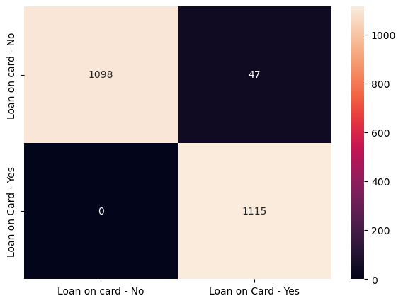

```
The accuracy score is  0.9792035398230089
The precision score is  0.979776247848537
The recall score is  0.979475982532751
The F1-score is 0.9792023630438796
The roc_auc_Scoreis 0.979475982532751
```

```python
print("========KNN  Regression Base Model==========")
#Base model KNN

KNNC = KNeighborsClassifier(n_neighbors= 5 )
KNNC.fit(X_train, Y_train)
predicted_labels_train = KNNC.predict(X_train)
predicted_labels_test = KNNC.predict(X_test)
test_train_analysis(Y_train,Y_test,predicted_labels_train,predicted_labels_test)
print(classification_report(Y_test,predicted_labels_test))


print("========KNN  Regression Final Model==========")
#hyper tuning parameter model using grid search

#leaf_size = list(range(1,50))
n_neighbors = list(range(1,30))
weights = ['uniform', 'distance']
metric = ['euclidean', 'manhattan', 'minkowski']
hyperparameters = dict( n_neighbors=n_neighbors,weights= weights,metric= metric)
knn2 = KNeighborsClassifier()
knn_gscv = GridSearchCV(knn2, hyperparameters, cv=10)
knn_gscv.fit(X_train_ros, y_train_ros)
print(knn_gscv.best_params_)
print(knn_gscv.best_score_)

#print('Best leaf_size:', knn_gscv.best_estimator_.get_params()['leaf_size'])
print('Best p:', knn_gscv.best_estimator_.get_params()['p'])
print('Best n_neighbors:', knn_gscv.best_estimator_.get_params()['n_neighbors'])
Y_pred = knn_gscv.predict(X_test_ros)

X_pred = knn_gscv.predict(X_train_ros)
print(classification_report(y_test_ros, Y_pred))
conf_metrix(y_test_ros, Y_pred)
print("The accuracy score is ", accuracy_score(y_test_ros, Y_pred))
print("The precision score is ", precision_score(y_test_ros, Y_pred,average="macro"))
print("The recall score is ", recall_score(y_test_ros, Y_pred,average="macro"))
print("The F1-score is", f1_score(y_test_ros, Y_pred,average="macro"))
print("The roc_auc_Scoreis",multiclass_roc_auc_score(y_test_ros, Y_pred, average="macro"))
```

```python
leaf_size = list(range(1,50))
n_neighbors = list(range(1,30))
weights = ['uniform', 'distance']
metric = ['euclidean', 'manhattan', 'minkowski']

#Convert to dictionary
knn_3 = KNeighborsClassifier()
hyperparameters = dict(leaf_size=leaf_size, n_neighbors=n_neighbors,weights= weights,metric= metric)

clf = GridSearchCV(knn_3, hyperparameters, cv=5)
best_model = clf.fit(X_train_ros,y_train_ros)

print('Best leaf_size:', best_model.best_estimator_.get_params()['leaf_size'])
print('Best p:', best_model.best_estimator_.get_params()['p'])
print('Best n_neighbors:', best_model.best_estimator_.get_params()['n_neighbors'])
Y_pred = best_model.predict(X_test_ros)
print("Best: %f using %s" % (best_model.best_score_, best_model.best_params_))
print(classification_report(y_test_ros, Y_pred))
```

```
Best leaf_size: 1
Best p: 2
Best n_neighbors: 2
Best: 0.975074 using {'leaf_size': 1, 'metric': 'manhattan', 'n_neighbors': 2, 'weights': 'distance'}
              precision    recall  f1-score   support

           0       1.00      0.96      0.98      1145
           1       0.96      1.00      0.98      1115

    accuracy                           0.98      2260
   macro avg       0.98      0.98      0.98      2260
weighted avg       0.98      0.98      0.98      2260
```

As per the comparision with Logistic regression,svm model and KNNModelthe best model is KNN model. In Base bodel for LoanOnCard=1 ,precision,reall and f1-score was not good. These parameters are improved on KNN Tuned balanced data. On comparing both the balanced KNN data set with and without leaf size factor, the performance is almost same.